# Intelligent Data Analysis — Homework 1.1

## Introduction

```r
load('heart.Rdata')
library(ggplot2)
library(vcd)
str(heart)
```

```
## 'data.frame':    462 obs. of  10 variables:
##  $ sbp      : int  160 144 118 170 134 132 142 114 114 132 ...
##  $ tobacco  : num  12 0.01 0.08 7.5 13.6 6.2 4.05 4.08 0 0 ...
##  $ ldl      : num  5.73 4.41 3.48 6.41 3.5 6.47 3.38 4.59 3.83 5.8 ...
##  $ adiposity: num  23.1 28.6 32.3 38 27.8 ...
##  $ famhist  : Factor w/ 2 levels "Absent","Present": 2 1 2 2 2 2 1 2 2 2 ...
##  $ typea    : int  49 55 52 51 60 62 59 62 49 69 ...
##  $ obesity  : num  25.3 28.9 29.1 32 26 ...
##  $ alcohol  : num  97.2 2.06 3.81 24.26 57.34 ...
##  $ age      : int  52 63 46 58 49 45 38 58 29 53 ...
##  $ chd      : int  1 1 0 1 1 0 0 1 0 1 ...
```

```r
head(heart)
```

```
##   sbp tobacco  ldl adiposity famhist typea obesity alcohol age chd
## 1 160   12.00 5.73     23.11 Present    49   25.30   97.20  52   1
## 2 144    0.01 4.41     28.61  Absent    55   28.87    2.06  63   1
## 3 118    0.08 3.48     32.28 Present    52   29.14    3.81  46   0
## 4 170    7.50 6.41     38.03 Present    51   31.99   24.26  58   1
## 5 134   13.60 3.50     27.78 Present    60   25.99   57.34  49   1
## 6 132    6.20 6.47     36.21 Present    62   30.77   14.14  45   0
```

## 1. Influence of family history on Corony Heart Disease

In this section we will investigate the influence of the family history on the chance of getting corony heart disease (CHD). That is, does the chance of getting CHD change given the absense or presence of heart diseases in the family? Furthermore, we will explore whether these influences change if we take subgroups of the data into account based on age.

The full research question that we consider is: *Does having a family history of coronary heart disease affect a patients chance of having coronary heart disease? Does this result change for patients younger than 40 years old? What about for patients aged 40 years or older?*

First, we will visualize the data for the three given groups: the full data set, the subgroup of subjects younger than 40, and the subgroup of people older than 40. Thereafter, we describe a data analysis plan that could be used to quantitatively address the research question.

### Visualization

We should start with visualizing the data to get an intuition for our quantitative data analysis plan. In this section we present figures for the three subject groups that are being considered.

#### All subjects considered

We use a bar plot to show the likelihood of having CHD given the absence or presence of a family history of heart diseases. This will serve as a good first intuition by spotting the differences between the Absent and Present groups.

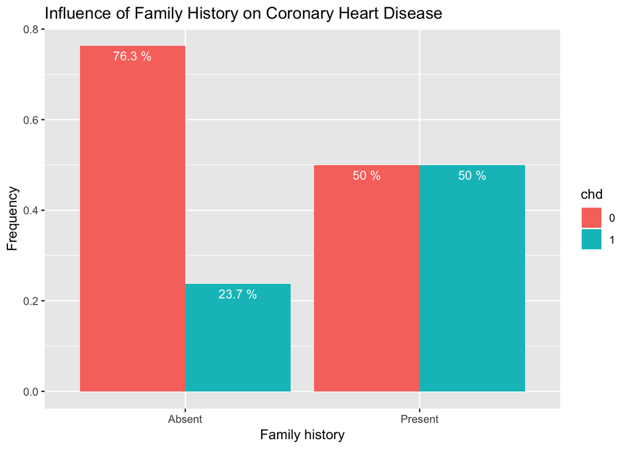

```r
# create table
counts <- table(heart$chd, heart$famhist)
# transform to dataframe
table_df <- as.data.frame(prop.table(counts,2))
# add column with formatted text
table_df$Freq_lab = paste(round(table_df$Freq * 100, digits=2), "%")
# bar plot
ggplot(data=table_df, aes(x=Var2, y=Freq, fill=Var1)) +
  geom_bar(stat="identity", position=position_dodge()) +
  geom_text(aes(label=Freq_lab), vjust=1.6, color="white",
            position = position_dodge(0.9), size=3.5) +
  xlab('Family history') +
  ylab('Frequency') +
  guides(fill=guide_legend(title='chd')) +
  ggtitle('Influence of Family History on Coronary Heart Disease')
```

More interesting that vanilla bar plots would be to look at a mosaic plot. This plot is used to see how much the group distributions deviate from the expected distributions. Furthermore, it colours the groups according to the Pearson residuals. The plot below shows that there is indeed significant difference between the two `famhist` groups, indicated by the dark colours. The colors here indicate that it will be less likely to have CHD when family history is absent and more likely to have CHD when family history is present.

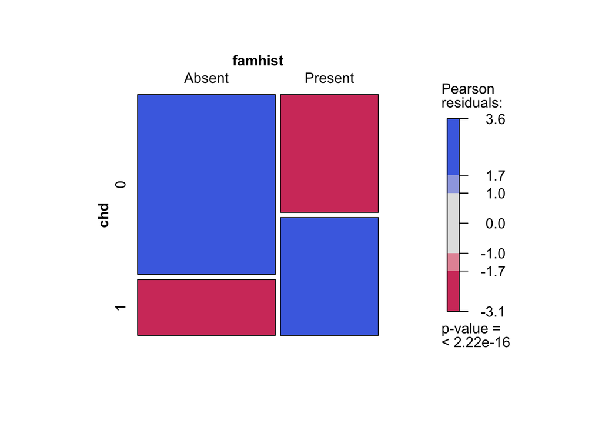

```r
# Draw the mosaic plot
countsx = xtabs(~famhist+chd, data=heart)
mosaic(countsx, gp=shading_max, split_vertical=TRUE)
```

#### Age < 40

We now take a subset of the data of only those subjects younger than 40 years. This plot shows that for this subgroup we have much less reason to believe that `famhist` is of incluence on having CHD.

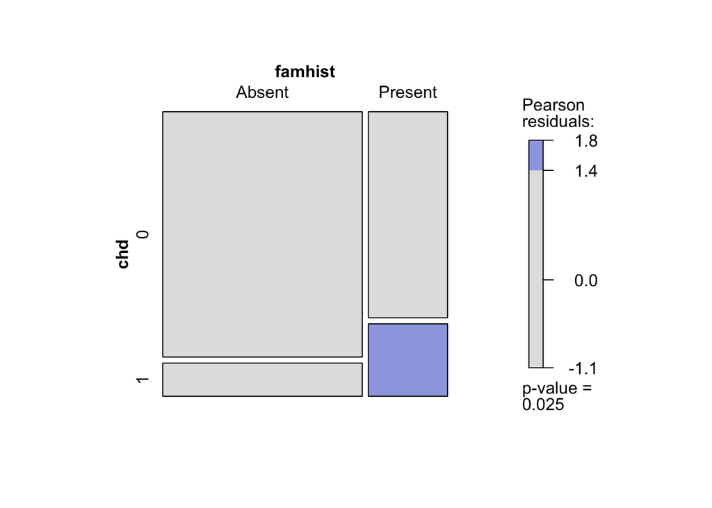

```r
# Split the dataset
heart_young <- heart[heart$age < 40,]
# Draw the mosaic plot
countsx_young = xtabs(~famhist+chd, data=heart_young)
mosaic(countsx_young, gp=shading_max, split_vertical=TRUE)
```

#### Age >= 40

Lastly, we consider the other part of the data, subjects of 40 years or older. Here again we see that `famhist` can be considered a explanatory variable for CHD.

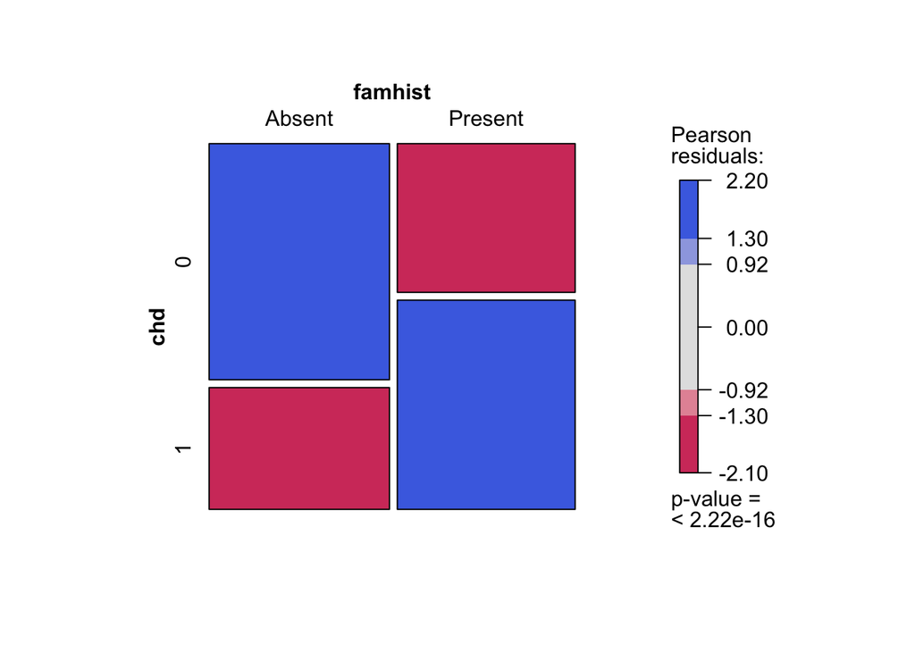

```r
# Split the dataset
heart_old <- heart[heart$age >= 40,]
# Draw the mosaic plot
countsx_old = xtabs(~famhist+chd, data=heart_old)
mosaic(countsx_old, gp=shading_max, split_vertical=TRUE)
```

### Data analysis plan

The mosaic plots presented above give us a good intuition about the influence of family history on CHD. Here we will present a plan to quantitively test our hypothesis.

We will use a chi-square test, which can be used to observe whether there is a significant difference between expected frequencies and observed frequencies in one or more categories. It will test the null hypothesis that the observed frequency is the same as the theoretical distribution. In other words, if the family history is of **no** influence. If we observe a low P-value, we can reject the null hypothesis and conclude that indeed family history is of influence on CHD.